# jawlik_checkpoint

Matthew A Jawlik

11/23/2017

## Jawlik Milestone Report

This is jawlik’s milestone report for the Coursera Capstone project. I chose to use the quantera package after having difficulties installing rjava and RWeka packages. In the end, the quantera package proved exceedingly simple to use.

## Setting up the Environment and downloading data

```r
library(stringr)
library(plyr)
library(tm)
library(quanteda)
library(wordcloud)
library(tokenizers)

temp <- tempfile()
download.file("https://d396qusza40orc.cloudfront.net/dsscapstone/dataset/Coursera-SwiftKey.zip",temp)
fns <- unzip(temp, junkpaths = TRUE, exdir = tempdir())
# Read in just the three English text files
us_twitter <- readLines(fns[7])
us_news <- readLines(fns[8])
us_blog <- readLines(fns[9])
```

## Exploratory Data Analysis

Perform some initial summary of the complete datasets:

```r
summ <- data.frame(
  fileName = c("us_twitter", "us_news", "us_blog"),
  records = c(length(us_twitter), length(us_news), length(us_blog)),
  minCharacters = c(min(nchar(us_twitter)), min(nchar(us_news)), min(nchar(us_blog))),
  maxCharacters = c(max(nchar(us_twitter)), max(nchar(us_news)), max(nchar(us_blog))),
  maxWords = c(max(str_count(us_twitter, "\\S+")), max(str_count(us_news, "\\S+")),
               max(str_count(us_blog, "\\S+"))),
  avgWords = c(mean(str_count(us_twitter, "\\S+")), mean(str_count(us_news, "\\S+")),
               mean(str_count(us_blog, "\\S+"))),
  medianWords = c(median(str_count(us_twitter, "\\S+")),
                  median(str_count(us_news,"\\S+")), median(str_count(us_blog, "\\S+")))
)
summ
```

```
##     fileName records minCharacters maxCharacters maxWords avgWords
## 1 us_twitter 2360148             2           140       47 12.86934
## 2    us_news 1010242             1         11384     1792 34.02406
## 3    us_blog  899288             1         40833     6630 41.51521
##   medianWords
## 1          12
## 2          31
## 3          28
```

### Perform deeper analysis

Take a sample of 10,000 records from each file, remove whitespace and convert to lowercase

```r
set.seed(999)
samp <- c(sample(us_twitter, 10000), sample(us_news, 10000),sample(us_blog,10000))
samp <- trimws(samp)
samp <- tolower(samp)
```

#### Tokenize words

Create unigrams, bigrams and trigrams using quanteda package (per instructions here: https://cran.r-project.org/web/packages/quanteda/vignettes/quickstart.html).

```r
unigrams <- dfm(samp, remove = stopwords("en"), remove_punct = TRUE,
                ngrams = 1, verbose = FALSE)
bigrams <- dfm(samp, remove = stopwords("en"), remove_punct = TRUE,
               ngrams = 2, verbose = FALSE)
trigrams <- dfm(samp, remove = stopwords("en"), remove_punct = TRUE,
                ngrams = 3, verbose = FALSE)
```

#### Look at most frequent unigrams, bigrams and trigrams

```r
topfeatures(unigrams, 15)
```

```
##     i   you    my  have    he    we  from    so  said   his   all    me
## 13332  6508  4633  4612  3985  3548  3494  3056  2897  2885  2806  2666
##   one about   has
##  2655  2486  2435
```

```r
topfeatures(bigrams, 15)
```

```
##   of_the   in_the   to_the   on_the  for_the    to_be   at_the  and_the
##     4123     3804     1942     1807     1683     1400     1260     1214
##     in_a with_the     is_a   it_was    it_is from_the   with_a
##     1110      992      923      913      831      802      797
```

```r
topfeatures(trigrams, 15)
```

```
##     one_of_the       a_lot_of    going_to_be        to_be_a     the_end_of
##            338            284            151            148            144
##     out_of_the    part_of_the     as_well_as       it_was_a    some_of_the
##            144            140            134            133            132
##      i_want_to     be_able_to thanks_for_the    the_rest_of   i_don't_know
##            120            120            116            107            104
```

#### Create barplots and wordclouds of most frequent ngrams

Unigrams

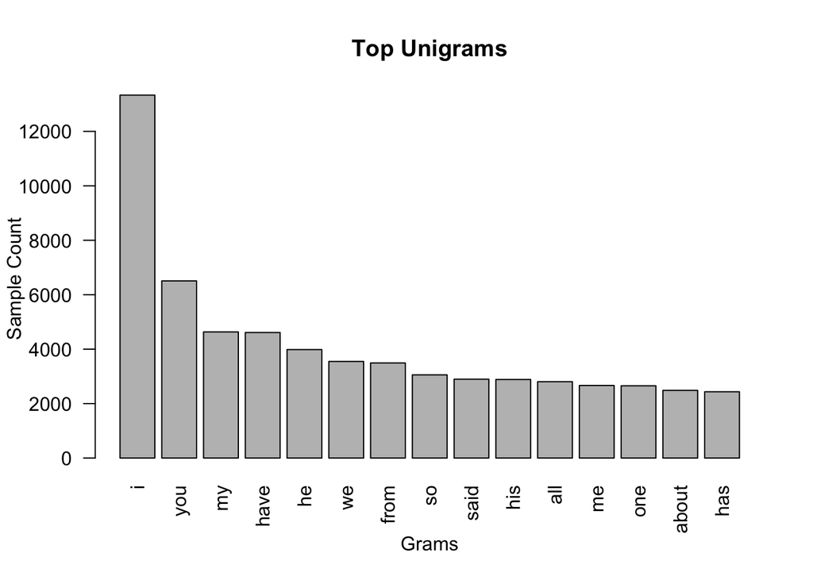

```r
top_uni <- topfeatures(unigrams, 15)
barplot(top_uni, main = 'Top Unigrams', xlab = 'Grams', ylab = 'Sample Count', axes = T,
        axisnames = T, las = 2)
```

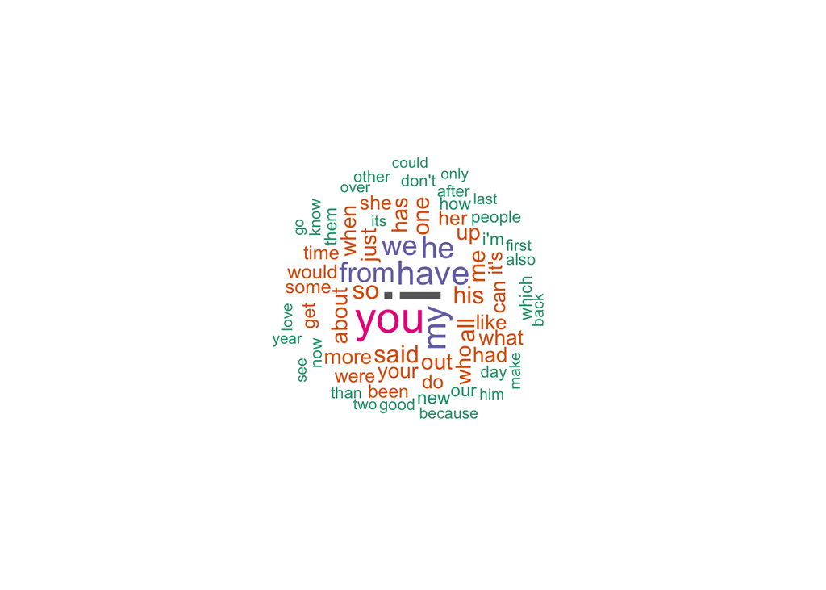

```r
textplot_wordcloud(unigrams, min.freq = 1000, random.order = FALSE, rot.per = .25,
                   colors = RColorBrewer::brewer.pal(8,"Dark2"))
```

Bigrams

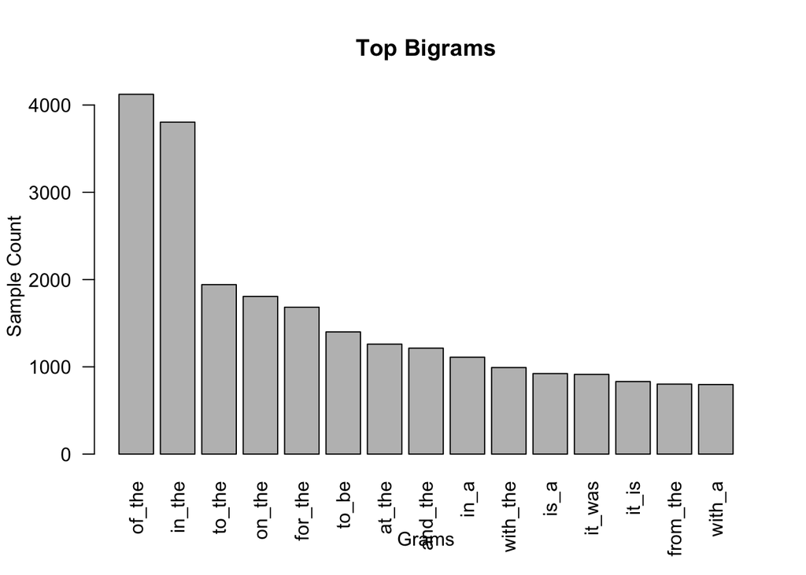

```r
top_bi <- topfeatures(bigrams, 15)
barplot(top_bi, main = 'Top Bigrams', xlab = 'Grams', ylab = 'Sample Count', axes = T,
        axisnames = T, las = 2)
```

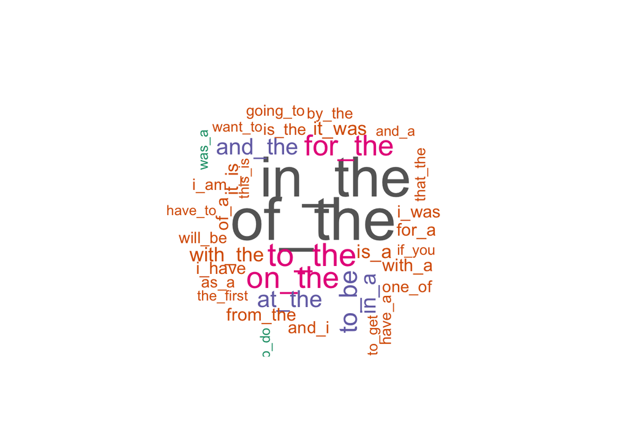

```r
textplot_wordcloud(bigrams, min.freq = 500, random.order = FALSE, rot.per = .25,
                   colors = RColorBrewer::brewer.pal(8,"Dark2"))
```

Trigrams

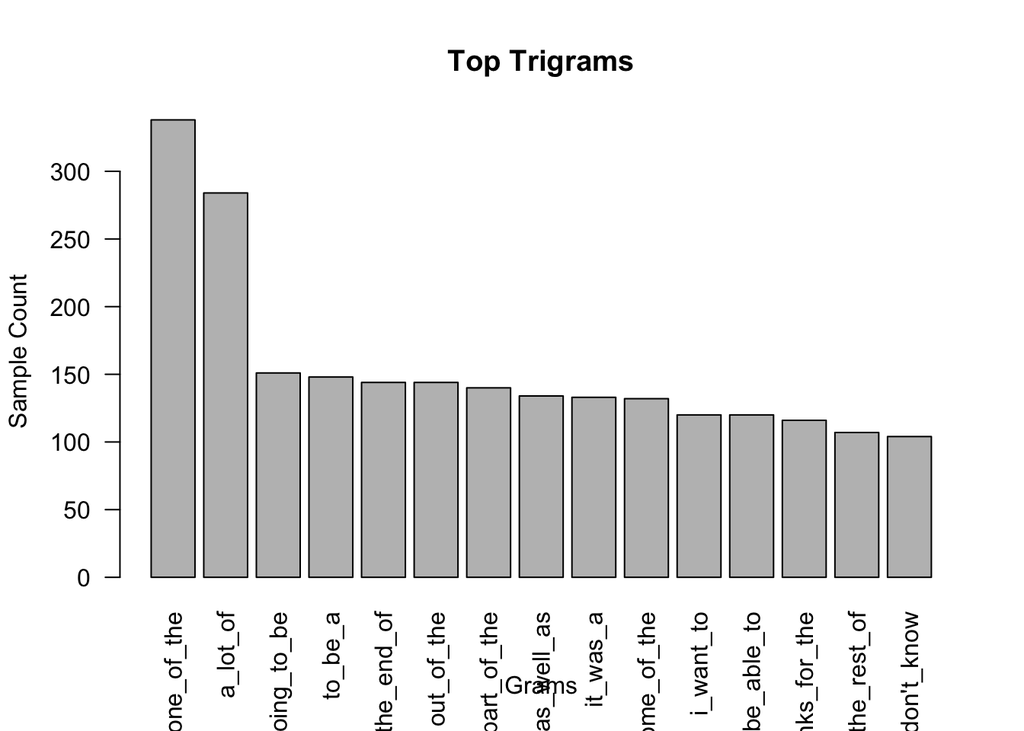

```r
top_tri <- topfeatures(trigrams, 15)
barplot(top_tri, main = 'Top Trigrams', xlab = 'Grams', ylab = 'Sample Count', axes = T,
        axisnames = T, las = 2)
```

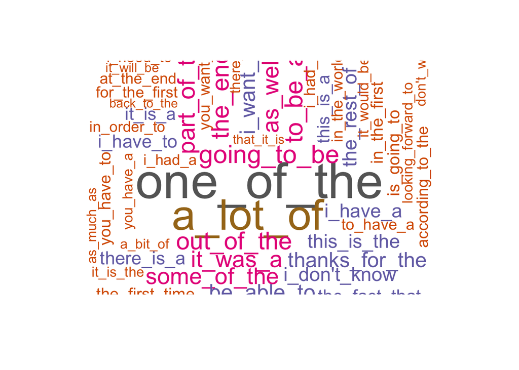

```r
textplot_wordcloud(trigrams, min.freq = 50, random.order = FALSE, rot.per = .25,
                   colors = RColorBrewer::brewer.pal(8,"Dark2"))
```

## Next Steps for Modeling

I haven’t been able to get the tokens() function working with corpus, which I would like to do. I’ll spend a bit more time on this, but after losing hours trying to get rJava and RWeka to install (without success) I may just move forward with the prediction algorithm.

For this algorithm, I plan on training on a dataset of half of the english data and testing on the remainder. The algorithm will attempt to predict the next word by matching existing typed words against the dictionary and offering the most likely options.